# Preliminary project Explanation:

**Also if we analyse the result below and compare it with this plot, we can see that the Random Forest model is better for predicting the price in this project, since it has a higher accuracy with the less errors ratio in compared to the other models.**

```python
print("R2  score by using MultiLinear Regression:", r2_Lin)
print("R2  score by using Decision Tree         :", r2_dt)
print("R2  score by using Random Forest         :", r2_rf)
```

```
R2  score by using MultiLinear Regression: 0.871720933476039
R2  score by using Decision Tree         : 0.9319433950819141
R2  score by using Random Forest         : 0.9546236157474985
```

```python
print("RMSE  score by using MultiLinear Regression:", rmselin)
print("RMSE  score by using Decision Tree         :", rmse_dt)
print("RMSE  score by using Random Forest         :", rmse_rf)
```

```
RMSE  score by using MultiLinear Regression: 0.050519734420225976
RMSE  score by using Decision Tree         : 0.036797499101295324
RMSE  score by using Random Forest         : 0.030046791736597828
```

> **In this part, we repeat the previous step by changing the X values. In this part, we omit the columns with high correlation with price and consider the other columns as new X to continue our investigation and find out which model and columns set are better for predicting price in our project**

```python
x1 = df_cars.drop(columns =["price","year","engineSize"])
y= df_cars.price
```

```python
k=4
selector = SelectKBest(f_regression,k=k)
selector.fit(x1,y)
best_feats = selector.get_support(indices=True)
x_best =x1.iloc[:,best_feats]
x_best.head()
```

|  | mileage | model_ I10 | model_ Santa Fe | transmission_Manual |
| --- | --- | --- | --- | --- |
| 0 | 0.125407 | 0.0 | 0.0 | 1.0 |
| 1 | 0.182842 | 0.0 | 0.0 | 0.0 |
| 2 | 0.274466 | 0.0 | 0.0 | 1.0 |
| 3 | 0.172378 | 1.0 | 0.0 | 1.0 |
| 4 | 0.240408 | 0.0 | 0.0 | 1.0 |

```python
x1_train, x1_test, y_train, y_test = train_test_split(x1, y, test_size=0.3, random_state=42)
print(x1_train.shape)
print(x1_test.shape)
print(y_train.shape)
print(y_test.shape)
```

```
(3341, 27)
(1433, 27)
(3341,)
(1433,)
```

```
actual value             predicted value
0.23437317443626593        0.33456761729811646
0.06998481130973246        0.13536609158596224
0.415819605094053        0.4031266696311403
0.3726837247341979        0.403450327315679
0.2754761070218483        0.2734425399120707
0.25236593059936907        0.24857643192393242
0.18226428321065544        0.2675371365468141
0.22895198037153874        0.24673410797831963
0.23016707559294308        0.2985614081685777
0.7195934104451455        0.6258589930528804
0.18226428321065544        0.17486586804529458
0.35494800794485337        0.39617395684036616
0.2983993457179577        0.3329695523042795
0.19850449818904076        0.19149288092856542
0.03502745647856058        -0.0039122414609583656
0.12379950928846829        0.13510189708568066
0.12641663745764692        0.16494621805429244
0.5069517466993808        0.3981674097691641
0.4392802897534759        0.44192501408940454
```

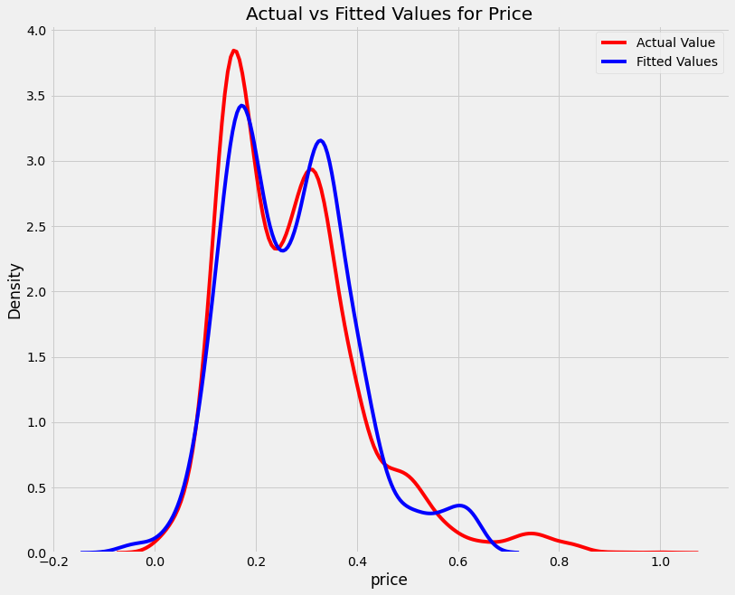

```python
linModel = LinearRegression()
linModel.fit(x1_train.values, y_train.values)
y_predLin = linModel.predict(x1_test.values)
print("actual value", "            predicted value")
i = 1
while i < 20:
    print(y_test.values[i],"      ",y_predLin[i])
    i += 1

plt.figure(figsize=(12, 10))
ax = sns.distplot(y, hist=False, color="r", label="Actual Value")
sns.distplot(y_predLin, hist=False, color="b", label="Fitted Values" , ax=ax)
plt.title('Actual vs Fitted Values for Price')
plt.legend()
plt.show()
```

```python
mseLin = mean_squared_error(y_test.values, y_predLin)
rmselin = np.sqrt(mean_squared_error(y_test.values, y_predLin))
print('The Mean Squared Error = {0:.4f}'.format(mseLin))
print('Root Mean Squared Error :{0:.4f}'.format(rmselin))
```

```
The Mean Squared Error = 0.0035
Root Mean Squared Error :0.0595
```

```python
r2_Lin = r2_score(y_test.values, y_predLin)
print('Goodness of Fit: {0:.2f}'.format(r2_Lin))
```

```
Goodness of Fit: 0.82
```

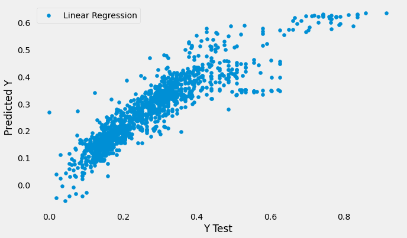

```python
plt.figure(figsize = (10,6))
plt.scatter(y_test, y_predLin, label='Linear Regression')
plt.xlabel('Y Test')
plt.ylabel('Predicted Y')
plt.legend(loc='upper left');
plt.grid()
```

```python
#cross validation
scores = cross_val_score(linModel, x1_train, y_train, scoring="neg_mean_squared_error", cv=10)
linModel_rmse_scores = np.sqrt(-scores)

linModel_r2_scores = cross_val_score(linModel, x1_train, y_train, scoring="r2", cv=10)



def show_scores(scores, model):
    print("      ",model,"    ")
    print("scores:",scores)
    print("scores_mean :", scores.mean())


show_scores(linModel_rmse_scores,linModel)
print("-"*10)
show_scores(linModel_r2_scores,linModel)
```

```
       LinearRegression()
scores: [0.05044419 0.05246223 0.06103618 0.0565169  0.05393032 0.05612132
 0.05849508 0.06159356 0.05460134 0.05149799]
scores_mean : 0.05566991094250119
----------
       LinearRegression()
scores: [0.85579192 0.83505457 0.79464953 0.82317108 0.84095551 0.81529993
 0.81440906 0.81414578 0.83610793 0.86656255]
scores_mean : 0.8296147843789166
```

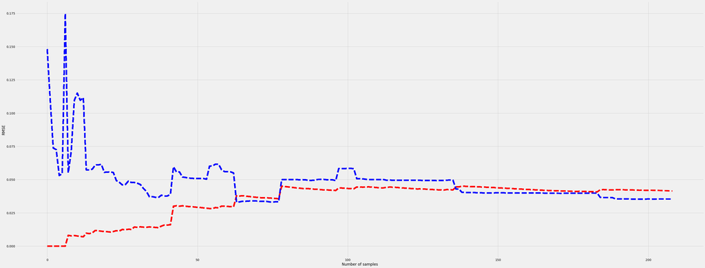

```python
def plot_learning_curves (model, X, y):
    X_train, X_val, y_train, y_val = train_test_split(X, y, test_size=0.3, random_state=42)
    train_errors, val_errors = [], []
    for m in range(1, len(X_train)):
        model.fit(X_train[:m], y_train[:m])
        y_train_pred = model.predict(X_train[:m])
        y_val_pred = model.predict(X_val)
        train_errors.append(mean_squared_error(y_train_pred, y_train[:m]))
        val_errors.append(mean_squared_error(y_val_pred, y_val))
        plt.rcParams["figure.figsize"] = (50, 20)
        plt.plot(np.sqrt(train_errors), 'r--', linewidth=6, label='train')
        plt.plot(np.sqrt(val_errors), 'b--', linewidth=6, label='val')
        plt.ylabel('RMSE')
        plt.xlabel('Number of samples')




plot_learning_curves(linModel, x1[:300], y[:300])
```

```
actual value             predicted value
0.23437317443626593         0.32242084355649026
0.06998481130973246         0.1003621918448417
0.415819605094053         0.5019277953031896
0.3726837247341979         0.48592125248276663
0.2754761070218483         0.2732094870896133
0.25236593059936907         0.29884332281808623
0.18226428321065544         0.1983876621100596
0.22895198037153874         0.19628461268839817
0.23016707559294308         0.2754994742376446
0.7195934104451455         0.8364294894263349
0.18226428321065544         0.17455310199789695
0.35494800794485337         0.5209720761771235
0.2983993457179577         0.28694940997780116
0.19850449818904076         0.20551466292791212
0.03502745647856058         0.0186937726369903
0.12379950928846829         0.12382287650426453
0.12641663745764692         0.11197569809557191
0.5069517466993808         0.5326556840752424
0.4392802897534759         0.48592125248276663
```

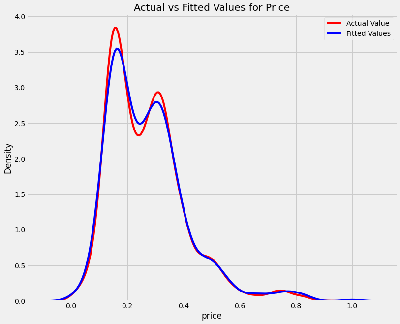

```python
DecisionTree_Model = DecisionTreeRegressor()
DecisionTree_Model.fit(x1_train.values, y_train.values)
y_dt_pred = DecisionTree_Model.predict(x1_test.values)
print("actual value", "            predicted value")
i = 1
while i < 20:
    print(y_test.values[i],"       ",y_dt_pred[i])
    i += 1

plt.figure(figsize=(12, 10))
ax = sns.distplot(y, hist=False, color="r", label="Actual Value")
sns.distplot(y_dt_pred, hist=False, color="b", label="Fitted Values" , ax=ax)
plt.title('Actual vs Fitted Values for Price')
plt.legend()
plt.show()
```

```python
mse_dt = mean_squared_error(y_test.values, y_dt_pred)
rmse_dt = np.sqrt(mean_squared_error(y_test.values, y_dt_pred))
print('The Mean Squared Error = {0:.4f}'.format(mse_dt))
print('Root Mean Squared Error :{0:.4f}'.format(rmse_dt))
```

```
The Mean Squared Error = 0.0018
Root Mean Squared Error :0.0422
```

```python
r2_dt = r2_score(y_test.values, y_dt_pred)
print('Goodness of Fit: {0:.2f}'.format(r2_dt))
```

```
Goodness of Fit: 0.91
```

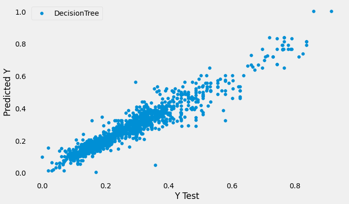

```python
plt.figure(figsize = (10,6))
plt.scatter(y_test, y_dt_pred, label='DecisionTree')
plt.xlabel('Y Test')
plt.ylabel('Predicted Y')
plt.legend(loc='upper left')
plt.legend()
plt.grid()
```

```python
scores = cross_val_score(DecisionTree_Model, x1_train, y_train, scoring="neg_mean_squared_error", cv=10)
DecisionTree_rmse_scores = np.sqrt(-scores)

DecisionTree_r2_scores = cross_val_score(DecisionTree_Model, x1_train, y_train, scoring="r2", cv=10)



def show_scores(scores, model):
    print("      ",model,"    ")
    print("scores:",scores)
    print("scores_mean", scores.mean())


show_scores(DecisionTree_rmse_scores,DecisionTree_Model)
print("-"*10)
show_scores(DecisionTree_r2_scores,DecisionTree_Model)
```

```
       DecisionTreeRegressor()
scores: [0.0423774  0.04254543 0.04886479 0.04438553 0.04061207 0.04085776
 0.03956199 0.03838584 0.04135941 0.03784534]
scores_mean 0.041679555911149316
----------
       DecisionTreeRegressor()
scores: [0.89514572 0.89137096 0.86564151 0.89069586 0.91161051 0.90460788
 0.91313647 0.92709941 0.90833178 0.93066687]
scores_mean 0.9038306959106196
```

```
actual value predicted value
0.23437317443626593         0.3323713050590024
0.06998481130973246         0.10954807804650077
0.415819605094053         0.4556097674962028
0.3726837247341979         0.45131907933169807
0.2754761070218483         0.2561189391284027
0.25236593059936907         0.2910033882462907
0.18226428321065544         0.19974319429839962
0.22895198037153874         0.18912186003037731
0.23016707559294308         0.27719336371071374
0.7195934104451455         0.7423297114148856
0.18226428321065544         0.17813716555672404
0.35494800794485337         0.4531398527865403
0.2983993457179577         0.3011928496319666
0.19850449818904076         0.201422128753359
0.03502745647856058         0.03990325972660355
0.12379950928846829         0.11990723215328908
0.12641663745764692         0.11180465007594341
0.5069517466993808         0.5094284379016243
0.4392802897534759         0.47723799509288495
```

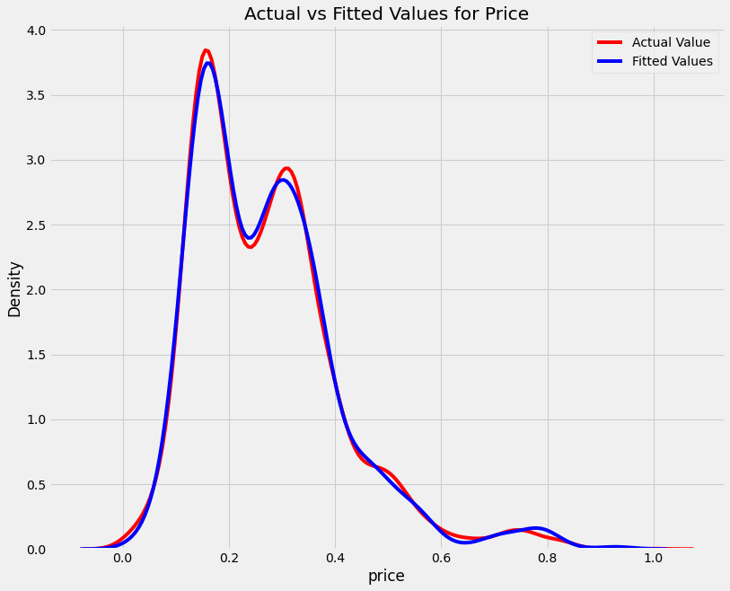

```python
randomForestModel = RandomForestRegressor()
randomForestModel.fit(x1_train.values, y_train.values)
y_rf_pred = randomForestModel.predict(x1_test.values)
print("actual value", "predicted value")
i = 1
while i < 20:
    print(y_test.values[i],"       ",y_rf_pred[i])
    i += 1
plt.figure(figsize=(12, 10))
ax = sns.distplot(y, hist=False, color="r", label="Actual Value")
sns.distplot(y_rf_pred, hist=False, color="b", label="Fitted Values" , ax=ax)
plt.title('Actual vs Fitted Values for Price')
plt.legend()
plt.show()
```

```python
mse_rf = mean_squared_error(y_test.values, y_rf_pred)
rmse_rf = np.sqrt(mean_squared_error(y_test.values, y_rf_pred))
print('The Mean Squared Error = {0:.4f}'.format(mse_rf))
print('Root Mean Squared Error :{0:.4f}'.format(rmse_rf))
```

```
The Mean Squared Error = 0.0012
Root Mean Squared Error :0.0345
```

```python
r2_rf = r2_score(y_test.values, y_rf_pred)
print('Goodness of Fit: {0:.2f}'.format(r2_rf))
```

```
Goodness of Fit: 0.94
```

```python
scores_randomforrest = cross_val_score(randomForestModel, x1_train, y_train, scoring="neg_mean_squared_error", cv=10)
randomForestModel_rmse_scores = np.sqrt(-scores_randomforrest)

randomForestModel_r2_scores = cross_val_score(randomForestModel, x1_train, y_train, scoring="r2", cv=10)

def show_scores(scores, model):
    print("      ",model,"    ")
    print("scores:",scores)
    print("scores_mean", scores.mean())


show_scores(randomForestModel_rmse_scores,randomForestModel)
print("-"*10)
show_scores(randomForestModel_r2_scores,randomForestModel)
```

```
       RandomForestRegressor()
scores: [0.03488171 0.03422601 0.03764459 0.03539716 0.03212558 0.0314211
 0.03154996 0.03245999 0.03173164 0.0314562 ]
scores_mean 0.033289393157439416
----------
       RandomForestRegressor()
scores: [0.93150723 0.9300576  0.91968305 0.92960292 0.94302227 0.93973645
 0.9466437  0.94558255 0.94571408 0.95083895]
scores_mean 0.9382388808606391
```

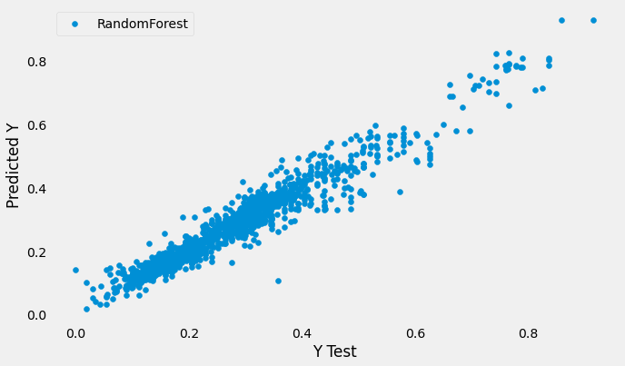

```python
plt.figure(figsize = (10,6))
plt.scatter(y_test, y_rf_pred, label='RandomForest')
plt.xlabel('Y Test')
plt.ylabel('Predicted Y')
plt.legend(loc='upper left');
plt.grid()
```

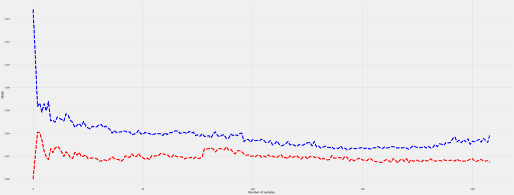

```python
plot_learning_curves(randomForestModel, x1[:300], y[:300 ])
```

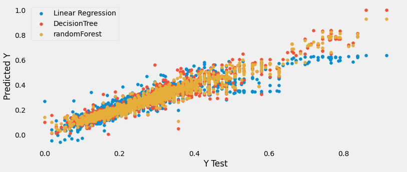

```python
plt.figure(figsize = (12,5))
plt.scatter(y_test, y_predLin, label='Linear Regression')
plt.scatter(y_test, y_dt_pred, label='DecisionTree')
plt.scatter(y_test, y_rf_pred, label='randomForest')
plt.xlabel('Y Test')
plt.ylabel('Predicted Y')
plt.legend(loc='upper left');
plt.grid()
```

```python
print("R2  score by using MultiLinear Regression:", r2_Lin)
print("R2  score by using Decision Tree         :", r2_dt)
print("R2  score by using Random Forest         :", r2_rf)
```

```
R2  score by using MultiLinear Regression: 0.822348652930147
R2  score by using Decision Tree         : 0.9105998428335186
R2  score by using Random Forest         : 0.9402123812737575
```

```python
print("RMSE  score by using MultiLinear Regression:", rmselin)
print("RMSE  score by using Decision Tree         :", rmse_dt)
print("RMSE  score by using Random Forest         :", rmse_rf)
```

```
RMSE  score by using MultiLinear Regression: 0.05945212959771072
RMSE  score by using Decision Tree         : 0.042174729374081135
RMSE  score by using Random Forest         : 0.03448965034328435
```

By comparing the results we collected in each step, we can conclude that our first set of columns, which we consider as X due to contain thos clumns with the higher corrolation give us the better result and the **Random Forest model** provide the better result which is more accurate besides the lower errors ratio incomparision with other models's result,so it's predicted price are closer to the actual values in comparision with other models(the decision tree model also have a great accuracy -more than 90%- which can consider it as a good model but random forest accuracy is the best .

According to the results I obtained during the project, Random Forest has an accuracy of 95% for predicting the price in the data of the first selected columns, which decreases in the second selection and reaches 94%.We can notice the same trend in the result of Rmse errors in both steps. So we can consider the **Random Forest model** as the final model for price prediction in our project.